# Explicación del Modelo de Tasas de Hurto y Agrupamiento Territorial con K-Means en Bogotá (2022-2026)

- Mostrar todo el código
- Ocultar todo el código
- Ver el código fuente

Taller de Programación en R - Maestría en Economía Aplicada (MECA)

Autores/as

Juan José Echeverry — 202616233

Miguelangel Palma — 202621481

Sergio Alejandro López Valderrama — 202111932

Gabriel Arturo Echeverry Castaño — 201016705

Olga Lucía Ramírez Contreras — 202624900

Juan Esteban Carvajal Cruz — 202614312

Fecha de publicación

16 de noviembre de 2026

Este documento explica paso a paso cómo funciona `scripts/04_clustering_kmeans.R`, el módulo encargado de agrupar las **19 localidades urbanas de Bogotá** en perfiles territoriales según sus tasas de hurto (2022–2026). Para que cualquier lector pueda seguirlo sin tropiezos, primero presentamos las herramientas matemáticas e intuitivas, luego la preparación de los datos, la búsqueda del número óptimo de grupos, la experimentación comparativa y, finalmente, el modelo definitivo y su exportación.

# 1 Conceptos clave antes de empezar

Antes de mirar código en R o tablas de resultados, veamos en lenguaje sencillo qué hace un modelo de agrupamiento y cómo se evalúa.

## 1.1 ¿Qué es agrupar localidades (*clustering* no supervisado)?

El *clustering* es una técnica de aprendizaje automático **no supervisado**: a diferencia de un modelo con etiquetas previas, aquí no le decimos al computador qué localidad pertenece a qué grupo. En su lugar, le entregamos las características numéricas de las $N = 19$ localidades (sus tres tasas de hurto promedio anual) y le pedimos que forme $K$ grupos (*clústeres*) cumpliendo dos metas simultáneas:

1. **Cohesión interna:** las localidades dentro de un mismo grupo deben ser lo más parecidas posible entre sí.
2. **Separación externa:** los grupos distintos deben estar claramente diferenciados unos de otros.

## 1.2 ¿Cómo medimos la cercanía entre dos localidades? (Distancias)

Para saber si dos localidades $a$ y $b$ se parecen, los algoritmos miden la “distancia” entre sus vectores de tasas estandarizadas $\mathbf{z}_a = (Z_{a,1}, Z_{a,2}, Z_{a,3})$ y $\mathbf{z}_b = (Z_{b,1}, Z_{b,2}, Z_{b,3})$. En este proyecto contrastamos dos métricas:

- **Distancia Euclidiana:** mide la **línea recta** más corta entre dos puntos en el espacio:
  $$d_{\text{Euclidiana}}(\mathbf{z}_a, \mathbf{z}_b) = \sqrt{\sum_{j=1}^{3} (Z_{aj} - Z_{bj})^2}$$
  Como eleva cada diferencia al cuadrado, penaliza mucho las diferencias grandes. Esto hace que localidades con valores extremos en una variable (como Los Mártires en hurto de motocicletas) ejerzan mucha atracción sobre los centros de grupo.
- **Distancia Manhattan:** suma las diferencias absolutas eje por eje, como caminar por las cuadras de una ciudad sin cruzar en diagonal:
  $$d_{\text{Manhattan}}(\mathbf{z}_a, \mathbf{z}_b) = \sum_{j=1}^{3} |Z_{aj} - Z_{bj}|$$
  Al no elevar al cuadrado, es menos sensible a valores extremos aislados y sirve como prueba de robustez frente a la distancia euclidiana.

## 1.3 ¿Por qué estandarizamos las variables? (Escalamientos y PCA)

Para que las tres modalidades pesen igual, probamos distintas formas de ponerlas en escala comparable:

- **Z-score (estandarización clásica):** resta el promedio $\bar{X}_j$ y divide por la desviación estándar $s_j$ ($Z_{ij} = (X_{ij} - \bar{X}_j)/s_j$). Todas las variables quedan centradas en $0$ con desviación estándar $1$.
- **Min-Max $[0, 1]$:** reescala cada variable para que su mínimo sea $0$ y su máximo sea $1$.
- **Robusto (Mediana / IQR):** centra en la mediana y divide por el rango intercuartílico ($\text{IQR} = Q_3 - Q_1$), reduciendo el peso de valores extremos.
- **Logarítmico `log(1 + x)` + Z-score:** comprime valores muy altos antes de estandarizar.
- **PCA (*Principal Component Analysis*):** combina las 3 variables correlacionadas en 2 ejes sintéticos ortogonales (`PC1` y `PC2`) que resumen la mayor parte de la varianza (`96,38%`), eliminando ruido redundante.

## 1.4 ¿Cómo evaluamos si un agrupamiento es bueno? (WSS, Silueta, Gap y ARI)

1. **Inercia intra-clúster ($\text{WSS}$):** suma de las distancias cuadradas de cada localidad al centro de su grupo. Cuanto menor es $\text{WSS}$, más compactos son los grupos (aunque siempre disminuye al aumentar $K$, por lo que no basta por sí sola para elegir $K$).
2. **Coeficiente de silueta ($S(i)$ y $\bar{S}$):** para cada localidad $i$, compara qué tan cerca está de su propio grupo ($a(i)$, distancia promedio intra-clúster) frente al grupo vecino más cercano ($b(i)$):
   $$S(i) = \frac{b(i) - a(i)}{\max\{a(i), b(i)\}} \in [-1, 1]$$
   - Un valor cercano a **$+1$** indica que la localidad está muy bien ubicada en su grupo.
   - Un valor cercano a **$0$** indica que está en la frontera entre dos grupos.
   - Un valor **negativo** (`n_silueta_neg`) indica que está más cerca de otro clúster que del suyo.
   - Por eso, **una silueta media $\bar{S}$ más alta significa mejor cohesión interna y mejor separación entre perfiles**.
3. **Estadístico Gap:** compara la dispersión observada de los grupos frente a $100$ simulaciones de datos puramente aleatorios (*bootstrap*). Un Gap positivo confirma que los grupos responden a una estructura real y no al azar.
4. **Índice de Rand Ajustado ($\text{ARI}$):** mide qué tanto coinciden dos clasificaciones distintas descontando el azar: $\text{ARI} = 1{,}0000$ significa que las 19 localidades quedaron exactamente en los mismos grupos, y valores mayores a $0{,}75$ indican alta estabilidad.

## 1.5 ¿Qué algoritmos comparamos?

- **K-Means:** divide las localidades alrededor de $K$ promedios (*centroides*) minimizando la distancia euclidiana intra-clúster ($\text{WSS}$). Se corre con `nstart = 50` reinicios aleatorios para evitar mínimos locales.
- **PAM (*Partitioning Around Medoids*):** funciona como K-Means, pero usa **localidades reales** como centros (*medoides*) en lugar de promedios teóricos, y admite tanto distancia euclidiana como Manhattan.
- **AGNES (Jerárquico Aglomerativo Ward.D2):** parte de 19 grupos individuales y va fusionando paso a paso el par de grupos que menos incrementa la varianza interna hasta quedar en $K = 3$.
- **GMM (*Gaussian Mixture Models*):** asume que cada clúster sigue una distribución normal multivariada (forma elíptica usando distancia de Mahalanobis) y asigna probabilidades de pertenencia vía algoritmo EM.

# 2 Preparación de los datos y receta base (`recipes`)

## 2.1 Por qué usamos tasas por 100.000 habitantes y estas 3 modalidades

Para construir una tipología territorial comparable entre localidades de distinto tamaño y estable en el tiempo, el análisis parte de **tasas por cada 100.000 habitantes** y de un **promedio anual por localidad** (2022–2026). Usar conteos brutos sesgaría el análisis hacia localidades muy pobladas como Suba o Kennedy (más de un millón de habitantes), mientras localidades céntricas con poca población residente pero enorme población flotante quedarían subestimadas.

$$\text{Tasa}_{it}^{(m)} = \frac{\text{Denuncias del delito } m \text{ en la localidad } i \text{ en el año } t}{\text{Población residente proyectada en la localidad } i \text{ en el año } t} \times 100.000$$

Elegimos las tres modalidades específicas (`hurto_personas`, `hurto_residencias` y `hurto_motos`) entre los 11 Delitos de Alto Impacto porque son los delitos patrimoniales cotidianos que más afectan la **percepción de inseguridad ciudadana** en Bogotá, explicando por qué el miedo al delito diverge de las cifras de homicidios (Restrepo & Moreno, 2007, *“Bogotá: ¿más crimen?, ¿más miedo?”*, *Desarrollo y Sociedad* 59, DOI: `10.13043/dys.59.5`; Encuesta de Percepción y Victimización de la CCB; ECSC del DANE). Además, excluir `tasa_hurto_total` del agrupamiento evita colinealidad exacta y doble conteo.

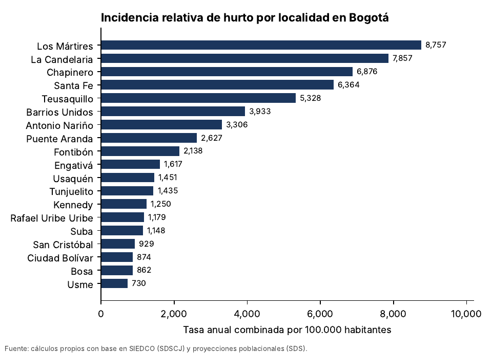

Figura 1: Tasa promedio anual de hurto total por cada 100.000 habitantes por localidad (2022–2026)

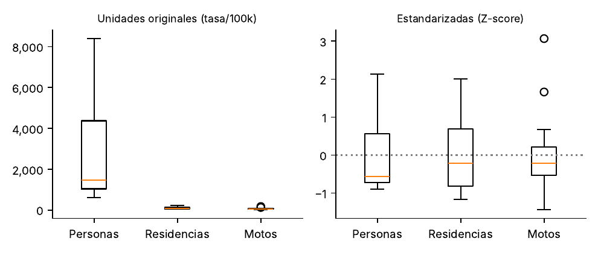

Figura 2: Distribución de las tres tasas antes y después de la estandarización (19 localidades)

## 2.2 Código en R: configuración, carga, promedio anual y receta Z-score (`Secciones 1 y 2`)

Primero configuramos el entorno reproducible (`options(scipen = 999)`, `set.seed(20261014)`), cargamos las librerías del ecosistema Tidyverse / Tidymodels (`recipes`, `broom`, `purrr`, `cluster`, `mclust`), resolvemos conflictos de nombres con `conflicted` y definimos las rutas portables con `here()`. Luego aplicamos la lógica declarativa de `{recipes}`, separando la definición de la transformación (`recipe() |> step_normalize()`), su estimación (`prep()`) y su aplicación (`bake()`):

```r
# 1. Configuración y Dependencias ----

## 1.1 Opciones globales y semilla ----
options(scipen = 999)
set.seed(20261014)

## 1.2 Carga de librerías ----
library(here)       # Rutas relativas portables
library(conflicted) # Evita colisiones silenciosas entre funciones
library(arrow)      # Lectura/escritura rápida en formato Parquet
library(readr)      # Exportación de tablas CSV
library(dplyr)      # Manipulación de datos (Tidyverse)
library(tidyr)      # Remodelado de tablas
library(purrr)      # Programación funcional sin bucles for
library(recipes)    # Preprocesamiento declarativo estilo tidymodels
library(broom)      # Extracción ordenada (tidy/glance) de modelos
library(cluster)    # PAM, siluetas y estadístico Gap
library(mclust)     # Mezclas Gaussianas (GMM) y Adjusted Rand Index (ARI)

## 1.3 Resolución explícita de conflictos ({conflicted}) ----
conflict_prefer("filter", "dplyr", quiet = TRUE)
conflict_prefer("lag",    "dplyr", quiet = TRUE)
conflict_prefer("select", "dplyr", quiet = TRUE)
conflict_prefer("map",    "purrr", quiet = TRUE)

## 1.4 Definición de rutas relativas ({here}) ----
ruta_datos_clean   <- here("data", "processed")
ruta_salida_tablas <- here("output", "tables")

if (!dir.exists(ruta_salida_tablas)) {
  dir.create(ruta_salida_tablas, recursive = TRUE, showWarnings = FALSE)
}

# 2. Preparación de Datos y Receta Principal (recipes) ----

## 2.1 Carga del panel delictivo y agregación promedio por localidad ----
panel_delitos <- read_parquet(file.path(
  ruta_datos_clean,
  "02_poblacion",
  "panel_delitos_poblacion_localidad.parquet"
))

matriz_localidad <- panel_delitos |>
  group_by(codigo_localidad, localidad) |>
  summarise(
    tasa_personas_prom = mean(tasa_hurto_personas, na.rm = TRUE),
    tasa_resid_prom    = mean(tasa_hurto_residencias, na.rm = TRUE),
    tasa_motos_prom    = mean(tasa_hurto_motos, na.rm = TRUE),
    tasa_total_prom    = mean(tasa_hurto_total, na.rm = TRUE),
    poblacion_prom     = mean(poblacion, na.rm = TRUE),
    .groups = "drop"
  )

## 2.2 Receta base de preprocesamiento: estandarización Z-score ----
receta_base <- recipe(
  ~ tasa_personas_prom + tasa_resid_prom + tasa_motos_prom,
  data = matriz_localidad
) |>
  step_normalize(all_numeric_predictors())

receta_base_prep <- prep(receta_base, training = matriz_localidad)
matriz_scale     <- bake(receta_base_prep, new_data = NULL) |> as.matrix()
rownames(matriz_scale) <- matriz_localidad$localidad
```

# 3 Selección del número óptimo de clústeres ($K = 2$ a $5$)

Con solo 19 localidades, evaluar $K$ entre `2` y `5` evita particiones triviales o grupos unitarios. Para cada $K$ ajustamos `kmeans(..., nstart = 50)` con `purrr::map()`, extraemos `tot.withinss` con `broom::glance()`, calculamos la silueta media con `cluster::silhouette()` sobre la distancia euclidiana y validamos contra 100 simulaciones bootstrap con `clusGap()`:

```r
# 3. Selección del Número Óptimo de Clústeres (K = 2 a 5) ----
dist_euclidea <- dist(matriz_scale, method = "euclidean")

diagnostico_k <- tibble(k = 2:5) |>
  mutate(
    modelo = map(k, function(k_val) {
      set.seed(20261014)
      kmeans(matriz_scale, centers = k_val, nstart = 50)
    }),
    silueta_media = map_dbl(modelo, function(km) {
      sil <- silhouette(km$cluster, dist_euclidea)
      round(mean(sil[, 3]), 4)
    }),
    wss = map_dbl(modelo, ~ round(glance(.x)$tot.withinss, 4))
  ) |>
  select(k, silueta_media, wss)

set.seed(20261014)
gap_kmeans <- clusGap(
  matriz_scale,
  FUNcluster = function(x, k) kmeans(x, centers = k, nstart = 50),
  K.max      = 5L,
  B          = 100L,
  verbose    = FALSE
)

k_optimo <- diagnostico_k$k[which.max(diagnostico_k$silueta_media)]
```

Tabla 1: Diagnóstico del número óptimo de agrupamientos $K$ mediante coeficiente de silueta e inercia intra-clúster

| Número de clústeres ($K$) | Silueta promedio | WSS (inercia interna) | Varianza explicada ($\text{BSS}/\text{TSS}$, %) |
| --- | --- | --- | --- |
| 2 | 0,5153 | 23,31 | 56,82 |
| 3 | 0,5416 | 13,58 | 74,85 |
| 4 | 0,4786 | 8,15 | 84,90 |
| 5 | 0,3792 | 5,90 | 89,07 |

Como muestra la Tabla 1 y la Figura 3, la combinación de métricas apunta de forma clara a **$K^{*}=3$**:

- **¿Qué significa una silueta promedio de `0,5416`?** En la escala estándar de calidad de agrupamiento ($-1$ a $+1$), valores entre `0,51` y `0,70` indican una **estructura sólida y bien definida** (lejos de `0,25` o menos, donde no hay grupos reales). En términos prácticos, $\bar{S}=0{,}5416$ significa que, en promedio, cada localidad está **más de dos veces más cerca de su propio grupo que del perfil vecino más cercano**, logrando fronteras claras entre territorios.
- **¿Qué es el `WSS` (`13,58`) y por qué equivale al `74,85%` de varianza explicada?** El **WSS** (*Within-Cluster Sum of Squares* o inercia interna) mide qué tan dispersas están las localidades **dentro** de su propio clúster: es la suma de las distancias al cuadrado entre cada localidad y el centro de su grupo. Cuando todas las 19 localidades están juntas en un solo grupo ($K=1$), su dispersión total es `54,00` ($3 \text{ variables} \times 18$). Al dividirlas en $K=3$ perfiles, esa dispersión interna cae a **`13,58`**, lo que significa que los 3 grupos capturan el **`74,85%`** de toda la variabilidad delictiva entre localidades ($\text{BSS}/\text{TSS} = (54{,}00 - 13{,}58)/54{,}00$).
- **¿Por qué no elegimos $K=4$ o $K=5$ aunque tengan menor `WSS`?** El `WSS` **siempre disminuye** al agregar más grupos (llegaría a `0` con $K=19$ grupos de una localidad). Por ejemplo, pasar de $K=3$ a $K=4$ reduce el `WSS` de `13,58` a `8,15`, pero hace caer la silueta de `0,5416` a `0,4786` (y a `0,3792` en $K=5$) porque parte artificialmente un grupo compacto en subgrupos demasiado cercanos entre sí. Por eso $K^{*}=3$ es el punto óptimo de equilibrio entre compacidad interna y separación entre perfiles.

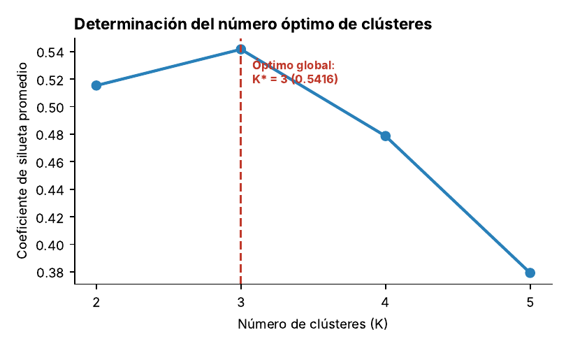

Figura 3: Coeficiente de silueta promedio para $K$ entre 2 y 5 (óptimo en $K^{*}=3$)

# 4 Experimentación y sensibilidad metodológica (`Sección 4`)

Antes de consolidar y exportar el modelo definitivo, la Sección 4 de `scripts/04_clustering_kmeans.R` evalúa si la partición en $K^{*}=3$ es estable al variar los **escalamientos** (`recipes` + PCA 2D), las **distancias** (Euclidiana vs. Manhattan) y las **familias de modelos** (K-Means, PAM, AGNES Ward.D2 y GMM).

## 4.1 Contraste de escalamientos y redimensionamiento PCA

Ajustamos el modelo de referencia `km_base` con el $K^{*}=3$ seleccionado, definimos `hornear_matriz()` para preparar y aplicar cualquier receta, extraemos la varianza explicada del PCA (`prcomp()`) y evaluamos los cinco espacios preprocesados mediante `evaluar_receta_kmeans()` e `imap_dfr()`:

```r
## 4.1 Modelo K-Means de referencia sobre la receta base ----
set.seed(20261014)
km_base  <- kmeans(matriz_scale, centers = k_optimo, nstart = 50)
sil_base <- silhouette(km_base$cluster, dist_euclidea)

## 4.2 Definición de recetas alternativas con {recipes} ----
receta_base_formula <- ~ tasa_personas_prom + tasa_resid_prom + tasa_motos_prom

hornear_matriz <- function(receta, datos) {
  receta |>
    prep(training = datos) |>
    bake(new_data = NULL) |>
    as.matrix()
}

receta_minmax <- recipe(receta_base_formula, data = matriz_localidad) |>
  step_range(all_numeric_predictors(), min = 0, max = 1)

receta_robusta <- recipe(receta_base_formula, data = matriz_localidad) |>
  step_mutate(
    tasa_personas_prom = (tasa_personas_prom - median(tasa_personas_prom)) / IQR(tasa_personas_prom),
    tasa_resid_prom    = (tasa_resid_prom    - median(tasa_resid_prom))    / IQR(tasa_resid_prom),
    tasa_motos_prom    = (tasa_motos_prom    - median(tasa_motos_prom))    / IQR(tasa_motos_prom)
  )

receta_log_z <- recipe(receta_base_formula, data = matriz_localidad) |>
  step_log(all_numeric_predictors(), offset = 1) |>
  step_normalize(all_numeric_predictors())

receta_pca2 <- recipe(receta_base_formula, data = matriz_localidad) |>
  step_normalize(all_numeric_predictors()) |>
  step_pca(all_numeric_predictors(), num_comp = 2)

pca_tasas <- prcomp(matriz_scale, center = FALSE, scale. = FALSE)
var_pca   <- summary(pca_tasas)$importance

## 4.3 Evaluación de K-Means (K = 3) en cada espacio preprocesado ----
evaluar_receta_kmeans <- function(receta, nombre_espacio) {
  mat_espacio <- hornear_matriz(receta, matriz_localidad)
  set.seed(20261014)
  km_esp  <- kmeans(mat_espacio, centers = 3L, nstart = 50)
  sil_esp <- silhouette(km_esp$cluster, dist(mat_espacio))

  tibble(
    espacio         = nombre_espacio,
    silueta_media   = round(mean(sil_esp[, 3]), 4),
    n_silueta_neg   = sum(sil_esp[, 3] < 0),
    wss             = round(glance(km_esp)$tot.withinss, 4),
    ari_vs_base     = round(adjustedRandIndex(km_esp$cluster, km_base$cluster), 4),
    pca_var_pc1     = round(var_pca[2, 1], 4),
    pca_var_pc2     = round(var_pca[2, 2], 4),
    pca_var_acum_2d = round(var_pca[3, 2], 4)
  )
}

catalogo_recetas <- list(
  "Z-score (base)"              = receta_base,
  "Min-Max [0, 1]"              = receta_minmax,
  "Robusto (Mediana / IQR)"     = receta_robusta,
  "Log(1 + x) + Z-score"        = receta_log_z,
  "PCA (PC1 + PC2 = 96,4% var)" = receta_pca2
)

tabla_sensibilidad_escalamientos <- imap_dfr(catalogo_recetas, evaluar_receta_kmeans)
```

**Mostrar código**

```r
sens_esc <- readr::read_csv(
  here::here("output", "tables", "tabla_sensibilidad_escalamientos_pca.csv"),
  show_col_types = FALSE
)
knitr::kable(sens_esc, digits = 4)
```

Tabla 2: Sensibilidad de K-Means (K = 3) a diferentes escalamientos y redimensionamiento PCA

| espacio | silueta_media | n_silueta_neg | wss | ari_vs_base | pca_var_pc1 | pca_var_pc2 | pca_var_acum_2d |
| --- | --- | --- | --- | --- | --- | --- | --- |
| Z-score (base) | 0.5416 | 1 | 13.5797 | 1.0000 | 0.7065 | 0.2573 | 0.9638 |
| Min-Max [0, 1] | 0.5619 | 0 | 1.0136 | 0.8484 | 0.7065 | 0.2573 | 0.9638 |
| Robusto (Mediana / IQR) | 0.4635 | 0 | 14.1014 | 1.0000 | 0.7065 | 0.2573 | 0.9638 |
| Log(1 + x) + Z-score | 0.4155 | 1 | 15.3351 | 0.3725 | 0.7065 | 0.2573 | 0.9638 |
| PCA (PC1 + PC2 = 96,4% var) | 0.5819 | 1 | 11.6271 | 1.0000 | 0.7065 | 0.2573 | 0.9638 |

- **Por qué `Z-score` es la mejor elección:** La estandarización `Z-score (base)` (`silueta = 0,5416`), el escalamiento `Robusto (Mediana / IQR)` (`silueta = 0,4635`, `wss = 14,1014`) y la proyección `PCA` (`PC1 + PC2`, que retiene el **96,38%** de la varianza con `silueta = 0,5819`) generan **exactamente la misma partición** ($\text{ARI} = 1{,}0000$). Aunque `PCA` sube ligeramente la silueta al comprimir el espacio a dos dimensiones, `Z-score` mantiene el mismo agrupamiento conservando la **interpretabilidad directa en las tres tasas originales** (indispensable para etiquetar *Céntrico*, *Comercial* y *Residencial*). Por el contrario, `Log(1 + x)` aplana las diferencias reales y cae en cohesión (`silueta = 0,4155`, $\text{ARI} = 0,3725$).

## 4.2 Contraste de distancias y modelos alternativos

Calculamos la matriz de distancias Manhattan, ajustamos **PAM**, **AGNES (Ward.D2)** y **GMM**, y consolidamos las métricas comparativas con `evaluar_particion()`:

```r
## 4.4 Contraste de distancias (Euclidiana vs. Manhattan) y modelos alternativos ----
dist_manhattan <- dist(matriz_scale, method = "manhattan")

pam_euc <- pam(dist_euclidea,  k = 3L)
pam_man <- pam(dist_manhattan, k = 3L)
hc_euc  <- cutree(hclust(dist_euclidea,  method = "ward.D2"), k = 3L)
hc_man  <- cutree(hclust(dist_manhattan, method = "ward.D2"), k = 3L)

set.seed(20261014)
gmm_fit <- Mclust(matriz_scale, G = 3L, verbose = FALSE)

evaluar_particion <- function(clusters_vec, dist_ref, nombre_modelo, metric_dist) {
  sil_obj  <- silhouette(clusters_vec, dist_ref)
  tamanios <- paste(sort(as.integer(table(clusters_vec)), decreasing = TRUE), collapse = " / ")

  tibble(
    modelo         = nombre_modelo,
    distancia      = metric_dist,
    silueta_media  = round(mean(sil_obj[, 3]), 4),
    n_silueta_neg  = sum(sil_obj[, 3] < 0),
    tamanios_grupo = tamanios,
    ari_vs_kmeans  = round(adjustedRandIndex(clusters_vec, km_base$cluster), 4),
    gap_k3         = round(gap_kmeans$Tab[3, "gap"], 4)
  )
}

tabla_comparacion_modelos <- bind_rows(
  evaluar_particion(km_base$cluster,        dist_euclidea,  "K-Means (base)",      "Euclidiana"),
  evaluar_particion(pam_euc$clustering,     dist_euclidea,  "PAM (Medoides)",      "Euclidiana"),
  evaluar_particion(pam_man$clustering,     dist_manhattan, "PAM (Medoides)",      "Manhattan"),
  evaluar_particion(hc_euc,                 dist_euclidea,  "AGNES (Ward.D2)",     "Euclidiana"),
  evaluar_particion(hc_man,                 dist_manhattan, "AGNES (Ward.D2)",     "Manhattan"),
  evaluar_particion(gmm_fit$classification, dist_euclidea,  "GMM (Mezcla Gauss.)", "Mahalanobis / EM")
)
```

**Mostrar código**

```r
comp_mod <- readr::read_csv(
  here::here("output", "tables", "tabla_comparacion_modelos_distancias.csv"),
  show_col_types = FALSE
)
knitr::kable(comp_mod, digits = 4)
```

Tabla 3: Contraste de modelos (K-Means, PAM, AGNES Ward y GMM) y distancias (Euclidiana vs. Manhattan) para K = 3

| modelo | distancia | silueta_media | n_silueta_neg | tamanios_grupo | ari_vs_kmeans | gap_k3 |
| --- | --- | --- | --- | --- | --- | --- |
| K-Means (base) | Euclidiana | 0.5416 | 1 | 12 / 5 / 2 | 1.0000 | 0.1545 |
| PAM (Medoides) | Euclidiana | 0.5251 | 0 | 13 / 5 / 1 | 0.8484 | 0.1545 |
| PAM (Medoides) | Manhattan | 0.4811 | 1 | 11 / 6 / 2 | 0.7859 | 0.1545 |
| AGNES (Ward.D2) | Euclidiana | 0.5251 | 0 | 13 / 5 / 1 | 0.8484 | 0.1545 |
| AGNES (Ward.D2) | Manhattan | 0.5359 | 0 | 13 / 5 / 1 | 0.8484 | 0.1545 |
| GMM (Mezcla Gauss.) | Mahalanobis / EM | 0.4994 | 2 | 11 / 6 / 2 | 0.8097 | 0.1545 |

- **Por qué `K-Means` sobre `Z-score` es el modelo definitivo:** Entre todos los algoritmos evaluados sobre el espacio `Z-score`, **K-Means (Euclidiana)** logra la **silueta media más alta (`0,5416`)** respaldada por un Gap positivo (`0,1545`). Tanto **PAM (Euclidiana)** como **AGNES Ward.D2 (Euclidiana y Manhattan)** obtienen siluetas ligeramente menores (`0,5251`–`0,5359`) con altísima concordancia ($\text{ARI} = 0,8484$, coincidiendo en **18 de 19 localidades**). La única diferencia es **Antonio Nariño** (el único caso frontera con silueta `-0,2116` en *k-means*), que en PAM/AGNES pasa al grupo residencial dejando a **Los Mártires** como un grupo unitario de una sola localidad (`13 / 5 / 1`). Por ello, *K-Means* logra la mejor separación global y mantiene tres perfiles territoriales interpretables (`12 / 5 / 2`).

# 5 Modelo final, perfiles territoriales y exportación (`Secciones 5 y 6`)

Confirmada la estabilidad del agrupamiento, consolidamos el modelo definitivo `km_final`, etiquetamos sus centroides de forma determinística con `broom::tidy()` (para que el clúster con mayor tasa de motos sea siempre *Comercial y Automotor*, el de mayor tasa de personas sea *Céntrico e Institucional* y el restante sea *Residencial y Periférico*) y exportamos todos los artefactos al final del script:

```r
# 5. Ajuste Definitivo, Etiquetado Determinístico y Auditoría ----

## 5.1 Etiquetado determinístico de centroides (broom::tidy) ----
km_final  <- km_base
sil_final <- sil_base

centroides_df <- tidy(km_final) |>
  mutate(cluster_raw = as.integer(cluster))

id_comercial <- centroides_df |>
  slice_max(tasa_motos_prom, n = 1) |>
  pull(cluster_raw)

id_centro <- centroides_df |>
  filter(cluster_raw != id_comercial) |>
  slice_max(tasa_personas_prom, n = 1) |>
  pull(cluster_raw)

id_residencial <- setdiff(1:3, c(id_comercial, id_centro))

df_clusters <- matriz_localidad |>
  mutate(
    cluster_raw       = km_final$cluster,
    silueta_localidad = round(as.numeric(sil_final[, 3]), 4),
    cluster_id = case_when(
      cluster_raw == id_centro      ~ 1L,
      cluster_raw == id_comercial   ~ 2L,
      cluster_raw == id_residencial ~ 3L
    ),
    cluster_nombre = case_when(
      cluster_id == 1L ~ "Céntrico e Institucional",
      cluster_id == 2L ~ "Comercial y Automotor",
      cluster_id == 3L ~ "Residencial y Periférico"
    ),
    perfil_seguridad = case_when(
      cluster_id == 1L ~ "Alta criticidad en hurto a personas y residencias (núcleo céntrico)",
      cluster_id == 2L ~ "Alta concentración de hurto automotor y motocicletas (corredor comercial)",
      cluster_id == 3L ~ "Tasa per cápita moderada en zonas de alta densidad residencial"
    )
  ) |>
  select(-cluster_raw) |>
  arrange(cluster_id, desc(tasa_total_prom))

## 5.2 Auditoría de asignaciones por localidad entre modelos ----
matriz_pca2 <- hornear_matriz(receta_pca2, matriz_localidad)
set.seed(20261014)
km_pca2 <- kmeans(matriz_pca2, centers = 3L, nstart = 50)

tabla_asignaciones_modelos <- matriz_localidad |>
  transmute(
    codigo_localidad = codigo_localidad,
    localidad        = localidad,
    kmeans_base      = km_final$cluster,
    pca2_kmeans      = km_pca2$cluster,
    pam_euclidiana   = pam_euc$clustering,
    pam_manhattan    = pam_man$clustering,
    agnes_euclidiana = hc_euc,
    agnes_manhattan  = hc_man,
    gmm_3            = gmm_fit$classification
  ) |>
  left_join(
    df_clusters |> select(codigo_localidad, cluster_nombre, silueta_localidad),
    by = "codigo_localidad"
  )

# 6. Exportación Conjunta de Resultados (Contrato Sentometrics / Shiny) ----

## 6.1 Guardado en data/processed/ y tablas en output/tables/ ----
archivo_salida_clusters <- file.path(ruta_datos_clean, "clusters_localidades_kmeans.parquet")
archivo_tabla_clusters  <- file.path(ruta_salida_tablas, "tabla_clustering_kmeans_perfiles.csv")

write_parquet(df_clusters, archivo_salida_clusters)
write_csv(df_clusters, archivo_tabla_clusters)
write_csv(tabla_sensibilidad_escalamientos, file.path(ruta_salida_tablas, "tabla_sensibilidad_escalamientos_pca.csv"))
write_csv(tabla_comparacion_modelos,        file.path(ruta_salida_tablas, "tabla_comparacion_modelos_distancias.csv"))
write_csv(tabla_asignaciones_modelos,       file.path(ruta_salida_tablas, "tabla_asignaciones_modelos_localidad.csv"))

message("✔ Asignaciones de clustering guardadas en: ", archivo_salida_clusters)
message("✔ Tabla de perfiles exportada en: ", archivo_tabla_clusters)
message("✔ Tablas de sensibilidad (recipes, PCA, distancias y modelos) guardadas en: ", ruta_salida_tablas)
```